# Camera2D

# Camera2D controls what’s on-screen in a 2D scene

`Camera2D` nodes can pan and zoom the view to show different portions of a 2D scene. You can attach them to any other moving entity to follow it.

In this guide, you will learn to:

- Set up a `Camera2D` node.
- Attach or move a camera to different nodes.
- Zoom in and out with a camera.
- Create a screen shake effect.

Contents:

- Setting up a Camera2D
- Camera2D’s key features
  - Switching between multiple cameras
  - Showing more of your scene with zoom
  - Fine-tuning camera placement with offset
  - Smoothing the camera’s movement
  - Preventing the camera from always following its target
  - Rotating the camera with the player
- How to use a Camera2D in practice
  - Following the player on screen
  - Letting the player zoom the camera
  - Limiting the camera’s movement
  - Showing multiple in-game views
  - Zooming the camera to fit multiple targets
  - Creating a screen shake effect
- Your questions
  - How can a Camera2D follow a node?
  - Why is my screen stretching?
  - How can I access my camera from anywhere?
  - What’s the difference between the physics and idle process modes?
  - How do I tell when objects are off-screen?
- Pro Tips
  - Understanding cameras and viewports
  - Offsetting the camera bypasses smoothing and other features

## Setting up a Camera2D

All `Camera2D` nodes are disabled by default. To enable them, make sure you enable the *Current* property in the *Inspector*.

To set up a `Camera2D`:

1. Create a scene.
2. Add a `Camera2D` node.
3. Select the node and turn on its *Current* property in the *Inspector*.

Here’s what a `Camera2D` will look like when you set it up for a default scene:

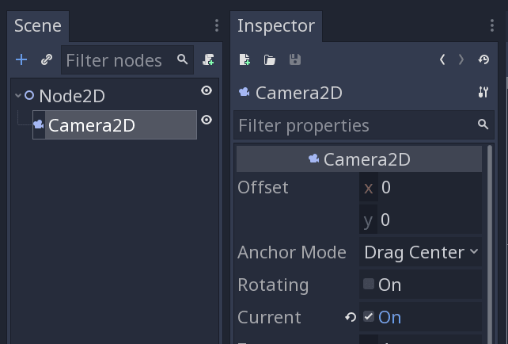

Only one camera can be active at a time in a given viewport. The last camera set to *Current* becomes the active one.

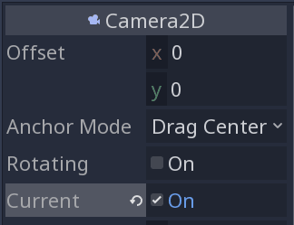

Now when you run the scene, your screen will display what the camera sees.

You can move the `Camera2D` in the editor and rerun the scene to show a different screen portion.

## Camera2D’s key features

Most of the in-game uses for camera rely on four key properties:

- *Current* enables the camera, and changes the active camera in a viewport.
- *Zoom* adjusts how much of the scene is on-screen at once.
- *Offset* fine-tunes the camera’s placement.
- *Smoothing Enabled* toggles the camera’s automated motion smoothing.

We’ll also cover three other features that are less common but still incredibly useful for some games:

- *Limit* prevents the camera from panning past a point in 2D space.
- *Drag Margin* holds the camera steady until the player has moved close enough to the edge of the screen.
- *Rotating* lets the camera rotate with its target, used in some games with tank controls.

### Switching between multiple cameras

You can switch between cameras at runtime by enabling the *Current* property of the camera you want to use.

### Showing more of your scene with zoom

*Zoom* plays a large part in depicting the scale of your level.

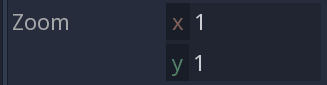

The property is counter-intuitive: the higher the camera’s *Zoom*, the more of your scene is visible. The lower the value, the more the camera zooms in.

A *Zoom* value higher than `1` will zoom out. For example, a value of `Vector2(4,4)` zooms out to `25%`.

[figure not shown]

A value lower than `1` zooms in. A *Zoom* value of `Vector2(0.25,0.25)` corresponds to a `400%` zoom level.

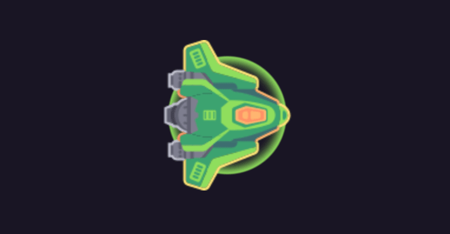

This is because the value scales the camera’s view bounds.

You’ll notice you can change the *Zoom* independently on the *x* and *y* axes. To prevent the screen’s contents from stretching, make sure that *x* and *y* of *Zoom* are both set to the same value.

### Fine-tuning camera placement with offset

Although a `Camera2D` can move by changing its `position`, there are other properties to frame your scene as needed.

To keep your camera pointed higher than where its position, adjust its *Offset* in the *Inspector*.

This moves your view relative to the camera’s current `position` and is great for effects like screen shakes, as we’ll see in a moment.

### Smoothing the camera’s movement

`Camera2D` nodes have a smoothing mode that interpolates their position over time.

Using smoothing is one way to prevent sudden jerks in camera movement and help make the camera movement feel more natural.

To enable smoothing, unfold the *Smoothing* category in the *Inspector* and click *Enabled*.

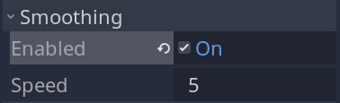

The *Smoothing -> Speed* property controls the speed at which the camera catches up with its target when the smoothing mode is enabled.

The higher the value, the faster the camera catches up to its target.

### Preventing the camera from always following its target

Not all games have a camera fully centered on the player. You can use the *Limit* property and the *Drag Margin* property to prevent the camera from always following its target.

- If you need to prevent the camera from moving past a 2D point in the scene (like the end of a level), use the *Limit* property.
- If you need to hold the camera steady during small movements, use the *Drag Margin* property.

To use camera limits, unfold the *Limit* category in the *Inspector* and adjust the *Left*, *Right*, *Top*, and *Bottom* properties.

To use the drag margin, enable the *Drag Margin V Enabled* and *Drag Margin H Enabled* properties in the *Inspector*. Then, unfold the *Drag Margin* category in the *Inspector* and adjust the *Left*, *Right*, *Top*, and *Bottom* properties.

We’ll cover how these work in much more depth when we look at using a `Camera2D` in practice.

### Rotating the camera with the player

For some games, you may want to rotate the camera with your player. This way, the player is always pointing upright on the screen.

A great example of this is in certain top-down shooters, where you can see more in front of you than behind you, just like your player character.

[figure not shown]

Game: *Contra III: The Alien Wars* (1992)

To enable camera rotation, enable *Rotating* in the *Inspector*.

You can then attach it to a rotating object, or change the camera’s `rotation` in code.

## How to use a Camera2D in practice

Now that we’ve looked at its key features, let’s look at some cool ways we can use a `Camera2D` node in practice.

### Following the player on screen

If we have a map that’s too large for our game window and want our *Player* to stay on screen, a *Camera2D* will pan our view to follow our player.

There are a few ways to do this, including:

- Adding a `Camera2D` as a child of the *Player* node.
- Using a `RemoteTransform2D` to forward the *Player*’s position to the `Camera2D`.

Both methods will need a custom *Player* node or another `Node2D` that can move around the scene to show this effect.

You can learn more about making *Player* nodes by reading the guide on KinematicBody2D.

#### Adding Camera2D as a child

To add a `Camera2D` as a child of the *Player*:

1. Select the *Player* node.
2. Add a `Camera2D` to the scene, as a child of the *Player*.
3. In the *Inspector*, turn on *Current*.

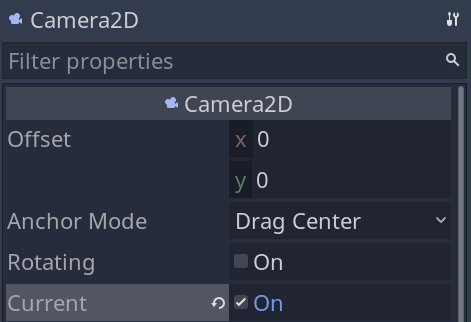

This camera setup is the simplest in Godot. It’s great when your camera only needs to follow one character through the entire game. This setup is common in racing games, Metroidvanias, rogue-likes, etc.

This is what the final result will look like:

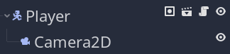

#### Using RemoteTransform2D to move a camera

There may be other cases where you need more flexibility in the way you structure your nodes.

You may not want to have your camera as a child of the player, but rather at another place in the node tree so other scripts can easily access the camera.

This is a case where `RemoteTransform2D` is your friend.

A `RemoteTransform2D` node pushes the transform of one `Node2D` to another, regardless of where the two are in the scene tree.

To set up a `RemoteTransform2D` to move your `Camera2D`:

1. Add a `Camera2D` to a 2D scene.
2. Add your *Player* node to the scene.
3. Add a `RemoteTransform2D` as a child of the *Player*.
4. Click *Assign* in the `RemoteTransform2D`’s *Remote Path* property.
5. Select `Camera2D` from the list of nodes.

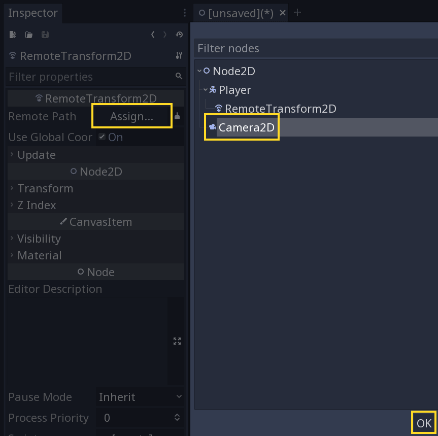

If your player is a physics body, you’ll want to set your camera’s *Process Mode* to *Physics*.

This makes it sync with the *Physics Process* callback and will prevent jittering.

This is what the final result will look like:

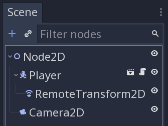

Overall, there are many ways to move a `Camera2D`. It depends on if the camera should follow one or several nodes during the game.

Some games will call for a more complex setup, but these two options cover your basics.

Visit the RemoteTransform2D guide for more use cases using `RemoteTransform2D`.

### Letting the player zoom the camera

Some games allow the player to have control over their camera’s zoom.

Giving the player control over zoom is powerful because it lets them see enemies or objectives sooner.

In some strategy games, zoom is always in the player’s control to see more of the board, letting them make better decisions.

[figure not shown]

Game: *Total War: ATILLA* (2015)

In other games, zooming out can be limited to special cases, like for spotting powerups.

You can create an action-oriented zoom-out to see the effects of zoom using a single key.

We can do this by altering the *Zoom* property of the camera, a `Vector2`. If the *Zoom*’s *x* and *y* properties aren’t the same, the screen will appear stretched.

When we press the interact key, we set the *Zoom* to a higher value to zoom out.

If we’re not pressing interact, we set the *Zoom* to its default value of `Vector2(1.0, 1.0)`.

```
extends Camera2D

func _physics_process(delta) -> void:
    # The "interact" input action is a custom one we put in our input map.
    # "interact" corresponds to the E key.
    if Input.is_action_pressed("interact"):
        # Instantly zooms out to 25% of the normal scale.
        zoom = Vector2(4.0, 4.0)
    else:
        # Zooms back in to normal.
        zoom = Vector2(1.0, 1.0)
```

You can use `lerp()` to smooth your camera’s zoom using `delta` in either `_process()` or `_physics_process()`.

```
extends Camera2D

const ZOOM_OUT_SPEED := 8.0
const ZOOM_IN_SPEED := 18.0

func _physics_process(delta: float) -> void:
    if Input.is_action_pressed("interact"):
        # A zoom value higher than 1 zooms *out*.
        zoom = lerp(zoom, Vector2(4.0, 4.0), delta * ZOOM_OUT_SPEED)
    else:
        zoom = lerp(zoom, Vector2(1.0, 1.0), delta * ZOOM_IN_SPEED)
```

Alternatively, you can use a `Tween` animation instead of `lerp()`.

See the Tween guide to learn more.

### Limiting the camera’s movement

While the camera follows the player in your scene, you may want to hide parts of the level that don’t need to be visible to the player as they move around the scene.

Metroidvania games feature a lot of secrets to be hidden, while platformers tend to prevent the camera from panning past certain points.

There are two ways to limit the camera’s movement: the *Limit* property and the *Drag Margin* property.

- *Limit* will stop the camera from panning past a certain point in 2D space.
- *Drag Margin* will only move the camera if the player moves far enough toward the edge of the screen.

#### Using limits to hide the edges of the level

You may want to hide a level edge so the player knows when they’ve reached the end of a level or hide an area that the player doesn’t need to see.

In these cases, limits are useful to prevent the camera from moving past a point in the stage.

In most 2D platformers, the camera won’t pan past the end of the level. Instead, the camera stops moving to show the player that they’ve reached the end.

[figure not shown]

Game: *Super Mario Bros. 3* (1988)

To use limits on a `Camera2D`, unfold the *Limit* category in the *Inspector* and adjust the *Left*, *Right*, *Top* and *Bottom* properties.

Optionally, to show the camera’s limits in the editor, unfold the *Editor* category in the *Inspector*, and enable *Draw Limits*.

This is what a camera with limits enabled will look like:

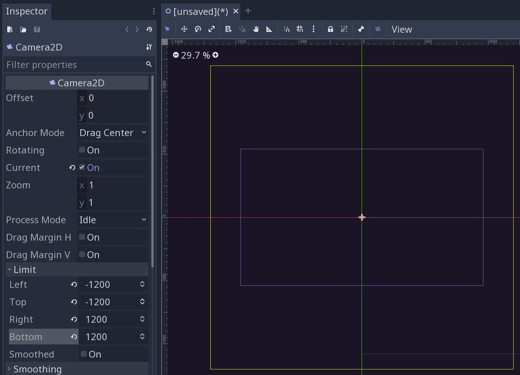

Increasing one of the direction values for *Limit* will allow the camera to pan further in that direction, away from the 2D origin. The 2D origin is the intersection of the x-axis and y-axis in the editor.

Additionally, you can enable *Limit -> Smoothing* so that the camera slows down before it hits one of the limits.

#### Using the drag margin to hold the camera steady

The drag margin prevents the camera from moving until the player has moved far enough from the screen center.

This is handy for keeping the camera steady when little movement is happening, like short jumps in a platformer. A drag margin is also a way to hide secrets until the player has moved close enough to pan the camera toward the secret.

To enable the drag margin, enable the *Drag Margin V Enabled* and *Drag Margin H Enabled* properties in the *Inspector*.

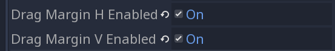

To adjust the drag margin size, unfold the *Drag Margin* category in the *Inspector*, then adjust *Left*, *Right*, *Top*, and *Bottom* properties.

Each of these direction properties controls how far the player has to move to the screen edge.

For example, setting *Drag Margin -> Left* to `1.0` will move the camera left when the player touches the left edge of the screen. Setting this property to `0.5` will move the camera left once the player has moved `50%` of the way to the left edge of the screen.

You can also show the drag margins in the editor to help visualize how it works. To show drag margins in the editor, unfold the *Editor* category in the *Inspector*, then enable *Draw Drag Margin*.

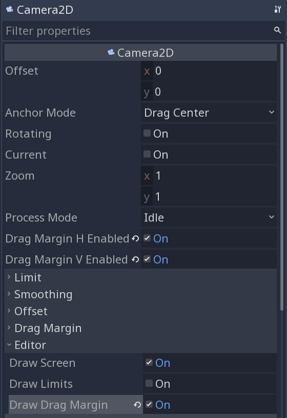

You can also use the drag margin to hide secrets that aren’t visible until the player has moved close enough. Unlike *Offset*, which constantly offsets the camera, *Drag Margin* is a way to dynamically offset the camera based on what needs to be seen.

In the screenshot below, the camera will not pan down until the player has moved far enough to push the drag margin downward.

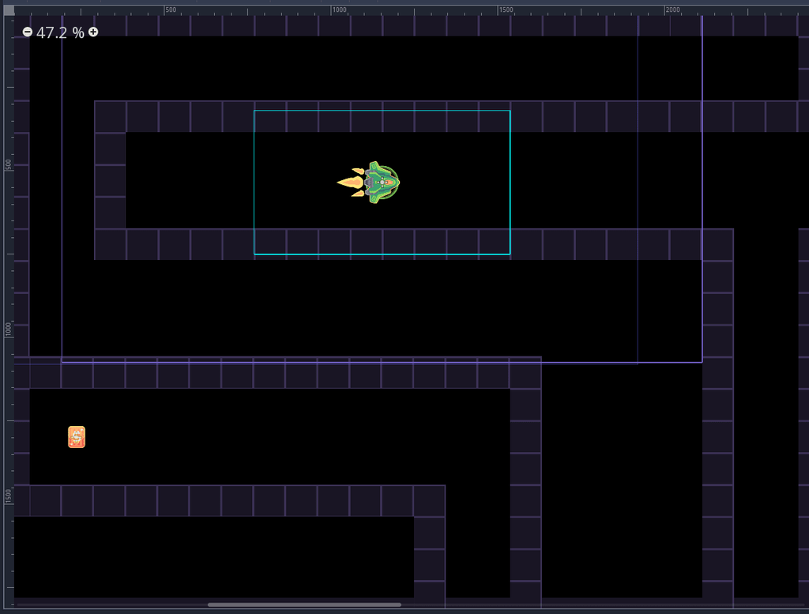

The player has to move away from the secret before getting close again, so the coin at the end is a surprise, despite it being directly below the starting location.

With careful level design planning, you can hide secrets or other shortcut areas like this.

### Showing multiple in-game views

You may want to show more information than what a `Camera2D` can show by default.

Fighting games need dynamic cameras, while a racing game may need a split-screen mode for multiplayer.

Some ways to show multiple in-game views are:

- Using multiple cameras.
- Making the camera follow multiple targets.
- Using multiple viewports.

#### Using multiple cameras

If you’re developing a multiplayer game, you may want to use separate `Camera2D` nodes with one camera on each player.

**Note:** This method will cause some jitter when switching to a camera with *Smoothing Enabled*. This method is ideal for snappy movement.

To use multiple cameras and switch between them, we’ll need to:

1. Create a scene with multiple cameras.
2. Add each camera to a group.
3. Access this group as an array.
4. Set the first camera in the array to *Current*.
5. Cycle through the group of cameras and set a new camera to *Current*.

Here’s how you can set up the scene to switch between multiple cameras.

Create a scene with multiple `Camera2D` nodes. In our demo, we attached two cameras to ships and added two others with a fixed position in the level.

Then, select and add all `Camera2D` nodes to a node group in the *Node* dock. This makes it easy to access the list of cameras in a script. We called our group `cameras`.

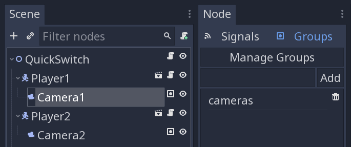

In a script, we get a list of all cameras in the running game by calling `get_tree().get_nodes_in_group("cameras")`. This function returns an array of all nodes that are part of the group. Here, our cameras.

```
# We cache the list of cameras to cycle in this array to later cycle through them.
var _cameras := []
# This variable holds a reference to the active camera.
var _current_camera: Camera2D

func _ready() -> void:
    # Here, we get the list of cameras and make the first one the current camera.
    _cameras = get_tree().get_nodes_in_group("cameras")
    _current_camera = _cameras[0]
    _current_camera.current = true
```

To cycle through the list of cameras, we can use `Array.push_back()` and `Array.pop_front()`:

1. `pop_front()` removes the first element in the array. It also returns it so we can move it elsewhere.
2. `push_back()` appends an element to the array.

When we combine the two functions, `_cameras.push_back(_cameras.pop_front())`, the array moves the first element to the end. This is super useful for cycling our camera references or other types of data in an array.

```
func _unhandled_input(event: InputEvent) -> void:
    # Interact is an input action we added to our project's input map.
    if event.is_action_pressed("interact"):
        cycle_cameras()


# This function cycles cameras by moving the current one to the end of the array.
# Like we did in _ready(), we store the current camera in a variable and make it
# the current one.
func cycle_cameras() -> void:
    _cameras.push_back(_cameras.pop_front())
    _current_camera = _cameras[0]
    _current_camera.current = true
```

#### Following multiple targets

Sometimes, a `Camera2D` should be able to follow multiple different nodes throughout a game. The player can be tasked with switching the camera to the node they need to see the most.

A top-down strategy game may move your camera to focus on a specific army in your command. Although your camera is locked onto one army, you still have the option to click on another army to bring them into focus.

Another situation you may want to use different targets is to show something important on-screen, like a boss enemy entering the scene.

This method uses `RemoteTransform2D`. To learn how to use `RemoteTransform2D` to lock a camera onto different targets, view the RemoteTransform2D guide.

#### Using multiple Viewports

You may want to create a new view on the screen for a split-screen multiplayer game or create a secondary map view next to your main game.

Showing the contents of two `Camera2D` nodes on-screen simultaneously requires using a `Viewport` node.

When you run your game, Godot automatically adds a Viewport node so you don’t have to. There can only be one *Current* camera for every `Viewport` node.

Adding multiple `Viewports` gives you more control over what is displayed on your screen.

To learn more about using multiple viewports, view the guide on Viewport nodes.

### Zooming the camera to fit multiple targets

Some games need a dynamic camera with an adaptive zoom to fit multiple targets on the screen at once.

There’s usually only one camera in a competitive fighting game, but it can pan and zoom to fit both players on screen.

There are two main parts to fitting the camera on multiple targets: panning the camera between two targets, and zooming the camera to fit them on the screen.

For the position, we get a reference to the two targets and calculate their mean position.

To do this, you need to:

1. Get a reference to the two targets.
2. Position the camera halfway through the targets.

One way to reference the player and the enemy is to use `NodePath`. After attaching a script to the camera, export a `NodePath` variable for each target.

```
extends Camera2D

# These variables allow us to pick the player and enemy nodes as paths in the inspector.
export var player_path := NodePath()
export var enemy_path := NodePath()

# With onready variables, we get the nodes corresponding to those paths.
onready var _player := get_node(player_path)
onready var _enemy := get_node(enemy_path)
```

To set the paths to the target nodes, go to the *Inspector* for the `Camera2D` and click *Assign*. Then, choose the corresponding player or enemy node.

Now we can get the player’s position with `_player.position`, and you can do the same for the enemy’s position with `_enemy.position`.

To calculate the mean position (halfway through the two targets), we add their positions and divide the result by two.

```
func _physics_process(_delta: float) -> void:
    position = (_enemy.position + _player.position) / 2
```

An alternative is to use `lerp()`, which supports vectors: `position = lerp(_player.position, _enemy.position, 0.5)`.

To zoom the camera to fit both targets, we compare the length of the viewport’s diagonal with the distance between the two targets. By calculating their ratio, we can approximate how much we need to zoom out to keep them both inside the frame.

The calculation we show you below isn’t perfect, but it’s one of the simplest possible and will work for you in many cases.

```
const MIN_ZOOM := 1.0
const MAX_ZOOM := 5.0

func _physics_process(_delta: float) -> void:
    #...

    # get_viewport_rect() is one way to get the rectangle for the space being rendered.
    # It gives us access to the viewport's resolution.
    var viewport_length_squared := get_viewport_rect().size.length_squared()
    # We use squared distance and the length of vectors whenever possible as these
    # two operations are faster than calculating regular distance with square root.
    var distance_squared: float = _player.position.distance_squared_to(_enemy.position)
    var ratio: float = distance_squared / viewport_length_squared

    # We calculate a uniform zoom in the [MIN_ZOOM, MAX_ZOOM] range.
    # We have to multiply our decimal value by `Vector2.ONE` as `zoom` is a `Vector2` property.
    zoom = Vector2.ONE * min(ratio + MIN_ZOOM, MAX_ZOOM)
```

Note it’s important to use the viewport’s size here over the `OS.window_size` and other similar properties: the viewport can be stretched to fit larger or smaller windows, so while using the `OS.window_size` may work in some cases, if the player stretches it, the zoom won’t work as well.

### Creating a screen shake effect

Screen shake is a popular effect to convey a hit or impact to the player. For example, when something explodes.

You can use the camera’s `offset`, which moves it relative to its current position, to create a screen shake effect.

Below, we cover two approaches to screen shake:

- Using random numbers, we get an erratic and energetic shake.
- Using a noise generator, we get a smoother and continuous motion.

#### Purely random screen shake

This first approach to shaking the screen relies on generating completely random numbers. This kind of shake feels erratic and powerful and can work great for strong hits and explosions.

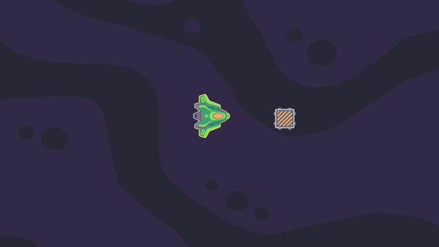

To shake the screen, we randomize the camera’s `offset` every frame and use a `Timer` to determine how long the shake should last.

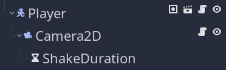

We use a constant to define the maximum distance the camera can move on either axis.

```
extends Camera2D

# Maximum shake offset on either axis in pixels.
const MAX_OFFSET := 25.0

onready var _shake_timer := $ShakeDuration
```

We use `_process()` to shake the view. By default, we turn processing off. When the player passes over a mine, we turn on processing and use the timer’s `timeout` signal to turn it back off.

```
# We use the timer and turn physics processing on and off to toggle the shake.
func _ready() -> void:
    set_process(false)
    _shake_timer.connect("timeout", self, "set_process", [false])

# When touching a mine, we start shaking.
func _on_Mine_body_entered(_body: PhysicsBody2D) -> void:
    # We restart the timer every time in case the player takes damage again
    # before the shake ended.
    _shake_timer.stop()
    _shake_timer.start()
    set_process(true)
```

When shaking, every frame, we calculate the timer’s progress and use `lerp()` to interpolate the `offset` back down to `Vector2(0, 0)`.

```
func _process(_delta) -> void:
    var random_offset := Vector2(
        rand_range(0.0, MAX_OFFSET), rand_range(0.0, MAX_OFFSET)
    )
    # The timer's progress gives us a multiplier to dampen the shake.
    var timer_progress: float = 1.0 - _shake_timer.time_left / _shake_timer.wait_time
    offset = lerp(random_offset, Vector2.ZERO, timer_progress)
```

This guide used a `Timer` node to control shake intensity, but in some cases, you might want to use a variable or a `Tween` node to get more fine-grained control over the shake effect’s intensity.

In the following example, we use a variable.

#### Noise-based screen shake

You can use a noise generator to get a smoother shake.

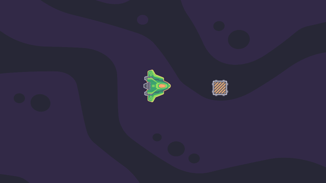

In this example, we control the shake with a property, so we don’t need a `Timer` node.

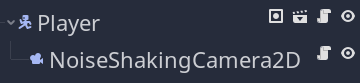

The whole shake logic happens in a script attached to the camera. We define two properties to control the shake’s maximum amplitude and current intensity between `0` and `1`.

```
# The maximum offset applied to the camera in pixels.
export var max_amplitude := 30.0

# We turn processing on and off through this property's setter function.
var shake_intensity := 0.0 setget set_shake_intensity

# We made our noise generator in the editor and saved it as a text resource
# file. This allows us to edit it in the Inspector while the game is running,
# with live reloading.
var _noise := preload("camera_noise.tres")


# We randomize the noise generator's seed to get a unique shake every time we
# play.
func _init() -> void:
    _noise.seed = randi()
```

The `_noise` is an `OpenSimplexNoise` resource we saved on the disk. It uses the following properties, which we set live while testing the camera shake:

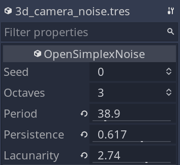

Here’s how it looks as a texture. Think of the white parts as moving the camera forward on either axis and the black parts moving it back.

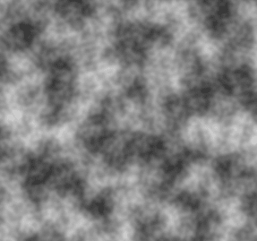

Changing the `shake_intensity` goes through a setter that toggles processing on and off.

```
func set_shake_intensity(intensity: float) -> void:
    shake_intensity = clamp(intensity, 0.0, 1.0)
    var is_shaking := not is_equal_approx(shake_intensity, 0.0)
    set_physics_process(is_shaking)
```

```
func _physics_process(delta: float) -> void:
    # Every frame we lower the intensity while the effect is active.
    # When the intensity reaches zero, the setter turns off processing.
    set_shake_intensity(shake_intensity - delta)
    # We use the time value to move along the noise generator's axes.
    # Using time gives us a smooth and continuous effect.
    var time_elapsed := OS.get_ticks_msec() / 20.0
    # We calculate a direction by getting two values from the noise generator.
    var random_direction := Vector2(
        _noise.get_noise_2d(time_elapsed, time_elapsed * 3.0),
        _noise.get_noise_2d(time_elapsed * 2.0, time_elapsed)
    ).normalized()
    # And we offset the camera's view.
    offset = random_direction * max_amplitude * shake_intensity * shake_intensity
```

Once again, when the player touches a mine, we start the shake. To do so, we set the `shake_intensity` to `1.0`.

```
func _on_Mine_body_entered(body: Node) -> void:
    set_shake_intensity(1.0)
```

## Your questions

### How can a Camera2D follow a node?

A `Camera2D` can follow a node by updating the camera’s position to the target node’s position. You can do this in a few ways:

- Make the `Camera2D` a child of any `Node2D`.
- Set the *Remote Path* of a `RemoteTransform2D` to a `Camera2D` elsewhere in the scene.
- Update the `position` or `global_position` of a `Camera2D` to the target node’s position.

### Why is my screen stretching?

Your screen can appear distorted or stretched if *Zoom*’s *x* value is different from its *y* value. A camera’s *Zoom* property is a `Vector2`, not a single value.

In the *Inspector*, select your `Camera2D` and check that the *x* and *y* values of the *Zoom* property are the same.

You can also check these values while the game is running, using the *Remote* tab in the *Scene* dock.

If you’re using code, one quick way to ensure both *x* and *y* of *Zoom* are set to the same value is to use the constant `Vector2.ONE`, which corresponds to `Vector2(1.0, 1.0)`. You can multiply this by a number to zoom your view uniformly. For example, `Vector.ONE * 2.0` is equivalent to `Vector2(2.0, 2.0)`.

### How can I access my camera from anywhere?

You may want to activate your screen shake effect for multiple reasons: an explosion going off, an enemy hitting the player or an animated cutscene.

This requires multiple objects to know where your camera is in your game.

To access your camera from anywhere, add the `Camera2D` node to a group in the *Node* dock, under the *Groups* tab.

Give it a group name and click *Add*. Now your enemies, or other objects, can use the function `get_tree().call_group()` to call a function from the camera’s group. Here’s a code sample for a group called `cameras`:

```
extends Node2D

func explode() -> void:
    # call `shake_screen()` on every node in the "cameras" group
    get_tree().call_group("cameras", "shake_screen")
```

Additionally, you can also save your `Camera2D` as a `.tscn` file and add it to *Autoload* in *Project Settings*. You can access this camera with the name given to the scene in the *Autoload* tab.

You can learn more about the *Autoload* tab on the [Godot documentation for Singletons](https://docs.godotengine.org/en/stable/getting_started/step_by_step/singletons_autoload.html).

### What’s the difference between the physics and idle process modes?

There are two processing loops in Godot games: idle, which corresponds to the `_process()` method, and physics, which corresponds to `_physics_process()`.

The main differences between the loops are:

- `_process()` runs once every frame, the same rate as your game’s “frames-per-second.”
- `_physics_process()` runs every physics step, when the physics engine updates.

### How do I tell when objects are off-screen?

If your game’s enemies start chasing your player before the enemy is even on-screen, you may want to disable their functionality until they’re visible. You may also want your enemies to wait for a signal to confirm they’re on-screen before engaging the player.

You can use `VisibilityEnabler2D` and `VisibilityNotifier2D` for these cases.

Both have different effects when they’re a child of another `Node2D`:

- `VisibilityEnabler2D` freezes and pauses different parts of nodes that are off-screen, without the need to use code.
- `VisibilityNotifier2D` provides helper signals like `screen_entered` and `screen_exited` for coding custom functions.

## Pro Tips

### Understanding cameras and viewports

Only one camera can be active at a time in a `Viewport`.

When you run your scene, Godot creates a default `Viewport` as the root of your game’s scene tree.

You can see the `Viewport` at runtime by clicking the *Remote* tab in the *Scene* dock.

The last camera set to *Current* becomes the active camera for its Viewport.

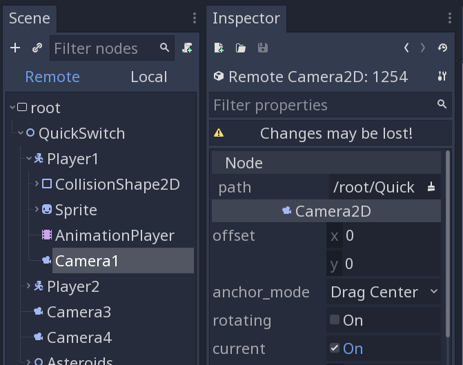

Under the hood, the `Camera2D` alters our view of the game by moving the contents of the `Viewport`.

For more information about the `Viewport` node, view the guide on Viewport nodes.

### Offsetting the camera bypasses smoothing and other features

The `Camera2D.offset` property is not affected by the camera’s smoothing and other features like smooth limits. You can use it to add custom movement on top of the built-in camera.

For instance, you might want the camera to smoothly follow the player and use drag margins. But you may also want to allow the player to peek forward when ducking or getting close to a door. You can animate the `offset` to do so.